# Reproducible Research: Peer Assessment 1

## Loading and preprocessing the data

Load the data:

```r
setwd("~/workspace/repdata-006/RepData_PeerAssessment1")

mydata <- read.csv("activity.csv", stringsAsFactors = FALSE)
```

Process/transform the data (if necessary) into a format suitable for your analysis:

```r
## Convert mydata$date from Character to Date
mydata$date <- as.Date(mydata$date, "%Y-%m-%d")
```

## What is mean total number of steps taken per day?

Make a histogram of the total number of steps taken each day:

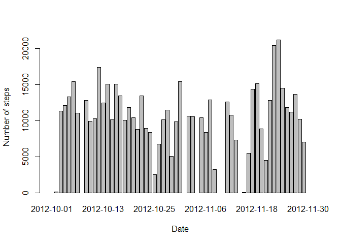

```r
date.sum <- tapply(mydata$steps, mydata$date, sum)

barplot(date.sum,
        xlab = "Date",
        ylab = "Number of steps")
```

Calculate and report the mean and median total number of steps taken per day:

```r
mean(date.sum, na.rm = TRUE)
```

```
## [1] 10766
```

```r
median(date.sum, na.rm = TRUE)
```

```
## [1] 10765
```

## What is the average daily activity pattern?

Make a time series plot (i.e. type = “l”) of the 5-minute interval (x-axis) and the average number of steps taken, averaged across all days (y-axis):

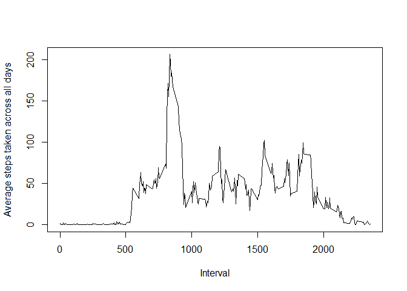

```r
## Aggregate steps by interval, and take the mean
interval.mean <- aggregate(mydata$steps ~ mydata$interval, FUN = mean)

## Give columns user-friendly names
colnames(interval.mean) <- c("interval", "steps.mean")

plot(interval.mean$steps.mean ~ interval.mean$interval,
     type = "l",
     xlab = "Interval",
     ylab = "Average steps taken across all days")
```

Which 5-minute interval, on average across all the days in the dataset, contains the maximum number of steps?

```r
interval.mean[interval.mean$steps.mean == max(interval.mean$steps.mean), "interval"]
```

```
## [1] 835
```